# Project 1: Wrangling, Exploration, Visualization

SDS322E

## Data Wrangling, Exploration, Visualization

### Janna Skinner jns2978

#### Introduction

The datasets I am using are lincoln_weather and SeatacWeather which I was able to find on the R data sets and packages. With these datasets I can compare and constrast weather trends in the Lincoln, Nebraska area as well as in the Seatlle-Tacoma Area. The variables will be month, year, max temp, min temp, and precipitation. While each of the datasets have more extensive variables I think the ones I chose will be beneficial in discovering any weather patterns with the associated areas. With these variables it will be interesting to find out if there is any correlation between the temperature or precipitation during certain times of the year in two very different geographical regions.

```r
library(tidyverse)
library(plyr)
library(dplyr)
packageVersion("dplyr")
```

```
## [1] '1.0.2'
```

```r
library(ggridges)
lincoln_weather
```

```
## # A tibble: 366 x 24
##    CST   `Max Temperatur… `Mean Temperatu… `Min Temperatur… `Max Dew Point …
##    <chr>            <int>            <int>            <int>            <int>
##  1 2016…               37               24               11               19
##  2 2016…               41               23                5               22
##  3 2016…               37               23                8               23
##  4 2016…               30               17                4               24
##  5 2016…               38               29               19               29
##  6 2016…               34               33               32               33
##  7 2016…               33               30               27               32
##  8 2016…               28               25               22               25
##  9 2016…               22                9               -4               17
## 10 2016…               31               11               -9               20
## # … with 356 more rows, and 19 more variables: `Mean Dew Point [F]` <int>, `Min
## #   Dewpoint [F]` <int>, `Max Humidity` <int>, `Mean Humidity` <int>, `Min
## #   Humidity` <int>, `Max Sea Level Pressure [In]` <dbl>, `Mean Sea Level
## #   Pressure [In]` <dbl>, `Min Sea Level Pressure [In]` <dbl>, `Max Visibility
## #   [Miles]` <int>, `Mean Visibility [Miles]` <int>, `Min Visibility
## #   [Miles]` <int>, `Max Wind Speed [MPH]` <int>, `Mean Wind Speed[MPH]` <int>,
## #   `Max Gust Speed [MPH]` <int>, `Precipitation [In]` <chr>, CloudCover <int>,
## #   Events <chr>, `WindDir [Degrees]` <int>, Month <fct>
```

```r
library(latticeExtra)
SeatacWeather
```

```
##     month day year max.temp record.max normal.max min.temp record.min
## 1 January   1 2007       43         58         45       34         10
## 2 January   2 2007       56         56         45       45          6
## 3 January   3 2007       48         58         45       43          6
## 4 January   4 2007       42         61         45       37         14
## 5 January   5 2007       43         55         45       31         15
## 6 January   6 2007       44         57         45       36         14
## 7 January   7 2007       49         59         45       40         19
##   normal.min precip record.precip normal.precip time.max time.min
## 1         35   0.13          1.37          0.17     1509       13
## 2         35   1.77          1.51          0.17     1000      135
## 3         35   1.01          1.01          0.17     1411      713
## 4         36   0.06          1.56          0.17     1535     1732
## 5         36   0.19          1.33          0.17     1312       55
## 6         36     NA          1.22          0.17       23      809
## 7         36   0.93          1.33          0.17     1544      127
##  [ reached 'max' / getOption("max.print") -- omitted 83 rows ]
```

#### Tidying: Reshaping

Since the datasets are already tidy I will be utilizing pivot longer/wider later on in the project at the merging step. To reshape my code I first started with the Lincoln weather data and separated the CST column so I could have a Year and Month column that would fit in nicely with the Seatac data. Next, I selected the variables I thought would be most useful to have in the dataset and removed the other unnecessary data. The I made sure to change the variable type of Year so it would match the other dataset. For the Seatac weather data, again I only selected the necessary variables that matched the other dataset and then I renamed the month observations to their number representatives so it would fit it nicely with the other dataset’s variable types. Lastly, I made sure all the variable types matched for each data set and created a new column for the location of the weather stats.

```r
lincoln_weather <- lincoln_weather %>% separate(CST, c("Year",
    "Month", "Day"), sep = "-")
lincoln_weather <- lincoln_weather %>% select(Year, Month, `Max Temperature [F]`,
    `Min Temperature [F]`, `Precipitation [In]`)
lincoln_weather <- lincoln_weather %>% dplyr::rename(MaxTemp = "Max Temperature [F]",
    MinTemp = "Min Temperature [F]", Precipitation = "Precipitation [In]")
lincoln_weather <- transform(lincoln_weather, Year = as.integer(Year))
lincoln_weather <- transform(lincoln_weather, Month = as.integer(Month))
lincoln_weather <- transform(lincoln_weather, Precipitation = as.numeric(Precipitation))
lincoln_weather <- lincoln_weather %>% mutate(Place = "Lincoln")

SeatacWeather <- SeatacWeather %>% select(year, month, max.temp,
    min.temp, precip)
SeatacWeather <- SeatacWeather %>% mutate(month = stringr::str_replace(month,
    "January", "1"))
SeatacWeather <- SeatacWeather %>% mutate(month = stringr::str_replace(month,
    "February", "2"))
SeatacWeather <- SeatacWeather %>% mutate(month = stringr::str_replace(month,
    "March", "3"))
SeatacWeather <- SeatacWeather %>% dplyr::rename(Year = "year",
    Month = "month")
SeatacWeather <- SeatacWeather %>% mutate(place = "Sea-Tac")
SeatacWeather <- transform(SeatacWeather, Month = as.integer(Month))
```

#### Joining/Merging

```r
Weather <- full_join(lincoln_weather, SeatacWeather, by = c("Year",
    "Month"))

Weather <- Weather %>% select(Month, Year, MaxTemp, max.temp,
    MinTemp, min.temp, Precipitation, precip, Place, place)
Weather <- Weather %>% pivot_longer(3:4, names_to = "names",
    values_to = "MaxTemp")
Weather <- Weather %>% pivot_longer(3:4, names_to = "names2",
    values_to = "MinTemp")
Weather <- Weather %>% pivot_longer(3:4, names_to = "names3",
    values_to = "Precip")
Weather <- Weather %>% pivot_longer(3:4, names_to = "names4",
    values_to = "Location")
Weather <- Weather %>% select(-names, -names2, -names3, -names4)
Weather <- Weather %>% na.omit()
Weather <- Weather %>% dplyr::rename(Precipitation = "Precip")
Weather <- Weather %>% select(Location, Month, Year, MaxTemp,
    MinTemp, Precipitation)
```

In the Lincoln data there are 366 observations and all of them are unique. In the Seatac data there are 90 observations and all the rows are unique as well. The datasets do not have any of the same data entry observations in common. This means that the Lincoln data has 366 observations that the Seatac data does not have, and the Seatac data has 90 observations that the Lincoln data does not contain.

I used full_join to combine these data sets so that no records or observations would be lost since they have data for different dates. The joined size of the data sets has 456 rows which displays how the two data sets were simply added together with no data, rows, or observations lost.

After joining I made sure to tidy the data so that each observation had a designated row with the maximum and minimum temperatures, amount of precipitation, location it was recorded, and the month and year. After tidying the joined data sets and removing all rows with NAs 89 rows were lost since the new total number of observations is 367.

#### Wrangling

```r
Weather <- Weather %>% mutate(MedianTemp = ((MaxTemp + MinTemp)/2))
Weather <- Weather %>% mutate(Location = str_remove_all(Location,
    "[-]"))

Weather %>% summarise(Avg = mean(MaxTemp), SD = sd(MaxTemp),
    Min = min(MaxTemp), Max = max(MaxTemp), UniqueTemps = n_distinct(MaxTemp))
```

```
##        Avg       SD Min Max UniqueTemps
## 1 62.97548 18.79795   8  98          76
```

```r
Weather %>% summarise(Avg = mean(MinTemp), SD = sd(MinTemp),
    Min = min(MinTemp), Max = max(MinTemp), UniqueTemps = n_distinct(MinTemp))
```

```
##        Avg      SD Min Max UniqueTemps
## 1 39.00817 17.3108 -26  72          75
```

```r
Weather %>% summarise(Avg = mean(Precipitation), SD = sd(Precipitation),
    Min = min(Precipitation), Max = max(Precipitation), UniqueAmounts = n_distinct(Precipitation))
```

```
##        Avg        SD Min  Max UniqueAmounts
## 1 0.103515 0.3090456   0 2.59            56
```

```r
Weather %>% group_by(Location) %>% summarise(Avg = mean(MedianTemp),
    SD = sd(MedianTemp), Min = min(MedianTemp), Max = max(MedianTemp),
    UniqueTemps = n_distinct(MedianTemp))
```

```
##        Avg       SD Min  Max UniqueTemps
## 1 50.99183 17.12394  -6 84.5         126
```

```r
Weather %>% group_by(Month) %>% summarise(Avg = mean(MedianTemp),
    SD = sd(MedianTemp), Min = min(MedianTemp), Max = max(MedianTemp),
    UniqueTemps = n_distinct(MedianTemp))
```

```
##        Avg       SD Min  Max UniqueTemps
## 1 50.99183 17.12394  -6 84.5         126
```

```r
Weather %>% group_by(Location) %>% dplyr::summarize(count = n())
```

```
## # A tibble: 2 x 2
##   Location count
##   <chr>    <int>
## 1 Lincoln    305
## 2 SeaTac      62
```

```r
Weather %>% group_by(Month) %>% dplyr::summarize(count = n())
```

```
## # A tibble: 12 x 2
##    Month count
##    <int> <int>
##  1     1    39
##  2     2    42
##  3     3    49
##  4     4    23
##  5     5    30
##  6     6    26
##  7     7    30
##  8     8    26
##  9     9    20
## 10    10    29
## 11    11    26
## 12    12    27
```

```r
Weather %>% group_by(Location, Month) %>% dplyr::summarize(count = n())
```

```
## # A tibble: 15 x 3
## # Groups:   Location [2]
##    Location Month count
##    <chr>    <int> <int>
##  1 Lincoln      1    22
##  2 Lincoln      2    20
##  3 Lincoln      3    26
##  4 Lincoln      4    23
##  5 Lincoln      5    30
##  6 Lincoln      6    26
##  7 Lincoln      7    30
##  8 Lincoln      8    26
##  9 Lincoln      9    20
## 10 Lincoln     10    29
## 11 Lincoln     11    26
## 12 Lincoln     12    27
## 13 SeaTac       1    17
## 14 SeaTac       2    22
## 15 SeaTac       3    23
```

```r
Weather %>% filter(Month == "1") %>% summarise(Avg = mean(MedianTemp),
    SD = sd(MedianTemp), Min = min(MedianTemp), Max = max(MedianTemp),
    UniqueTemps = n_distinct(MedianTemp))
```

```
##        Avg       SD Min  Max UniqueTemps
## 1 33.02564 9.139956  11 50.5          31
```

```r
Weather %>% filter(Month == "6") %>% summarise(Avg = mean(MedianTemp),
    SD = sd(MedianTemp), Min = min(MedianTemp), Max = max(MedianTemp),
    UniqueTemps = n_distinct(MedianTemp))
```

```
##        Avg       SD  Min Max UniqueTemps
## 1 73.48077 5.750619 62.5  82          19
```

```r
Weather %>% filter(Location == "Lincoln") %>% select(Precipitation,
    MinTemp, MaxTemp) %>% arrange(desc(Precipitation))
```

```
## # A tibble: 305 x 3
##    Precipitation MinTemp MaxTemp
##            <dbl>   <int>   <int>
##  1          2.59      60      83
##  2          2.07      39      49
##  3          1.82      41      46
##  4          1.72      42      61
##  5          1.57      40      45
##  6          1.42      66      96
##  7          1.27      49      74
##  8          1.07      43      63
##  9          1.06      66      93
## 10          0.92      59      74
## # … with 295 more rows
```

```r
Weather %>% filter(Location == "SeaTac") %>% select(Precipitation,
    MinTemp, MaxTemp) %>% arrange(desc(Precipitation))
```

```
## # A tibble: 62 x 3
##    Precipitation MinTemp MaxTemp
##            <dbl>   <int>   <int>
##  1          1.77      45      56
##  2          1.01      43      48
##  3          0.93      40      49
##  4          0.85      50      53
##  5          0.36      36      44
##  6          0.25      37      44
##  7          0.25      48      51
##  8          0.24      41      50
##  9          0.19      31      43
## 10          0.18      28      35
## # … with 52 more rows
```

```r
library(knitr)
library(gt)

table1 <- Weather %>% summarize_at(c(4:7), .funs = list(mean = mean,
    sd = sd, min = min, max = max, unique = n_distinct)) %>%
    pivot_longer(1:20, names_to = "names", values_to = "values") %>%
    separate(names, into = c("name", "stat")) %>% pivot_wider(names_from = "name",
    values_from = "values")

table1 %>% gt %>% tab_header(title = md("**Summary Statistics**"),
    subtitle = md("A table of my `Weather` summary statistics")) %>%
    tab_spanner(label = "Variables", columns = c("stat", "MaxTemp",
        "MinTemp", "Precipitation", "MedianTemp"))
```

**Summary Statistics**

A table of my `Weather` summary statistics

| Variables stat | Variables MaxTemp | Variables MinTemp | Variables Precipitation | Variables MedianTemp |
| --- | --- | --- | --- | --- |
| mean | 62.97548 | 39.00817 | 0.1035150 | 50.99183 |
| sd | 18.79795 | 17.31080 | 0.3090456 | 17.12394 |
| min | 8.00000 | -26.00000 | 0.0000000 | -6.00000 |
| max | 98.00000 | 72.00000 | 2.5900000 | 84.50000 |
| unique | 76.00000 | 75.00000 | 56.0000000 | 126.00000 |

Next, I compared the Median Temperature statistics for the winter in Month 1 and the summer at Month 6. The avg, min, and max and significant differences as predicted. Lastly, I compared the difference of precipitation in Lincoln and SeaTac. I was surprised to see that Lincoln had a higher maximum amount of precipitation. However, this observation could be due to the fact that Lincoln has more data entries than SeaTac.

#### Visualizing

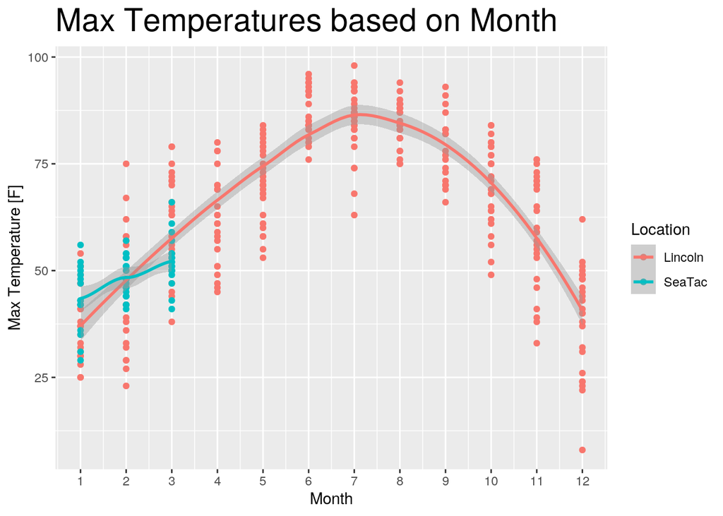

```r
Weather %>% ggplot(mapping = aes(x = Month, y = MaxTemp, color = Location)) +
    geom_point() + geom_smooth() + ylab("Max Temperature [F]") +
    scale_x_continuous(breaks = seq(0, 12, 1)) + ggtitle("Max Temperatures based on Month") +
    theme(plot.title = element_text(size = rel(2)))
```

The plot shows the gradual change in the maximum temperatures over the course of 12 months. The red shows the Lincoln location while the teal represents SeaTac. This shows that there is an increase in temperature from January to March in both locations. For Lincoln, it appears that the peak in max temperature occurs in July.

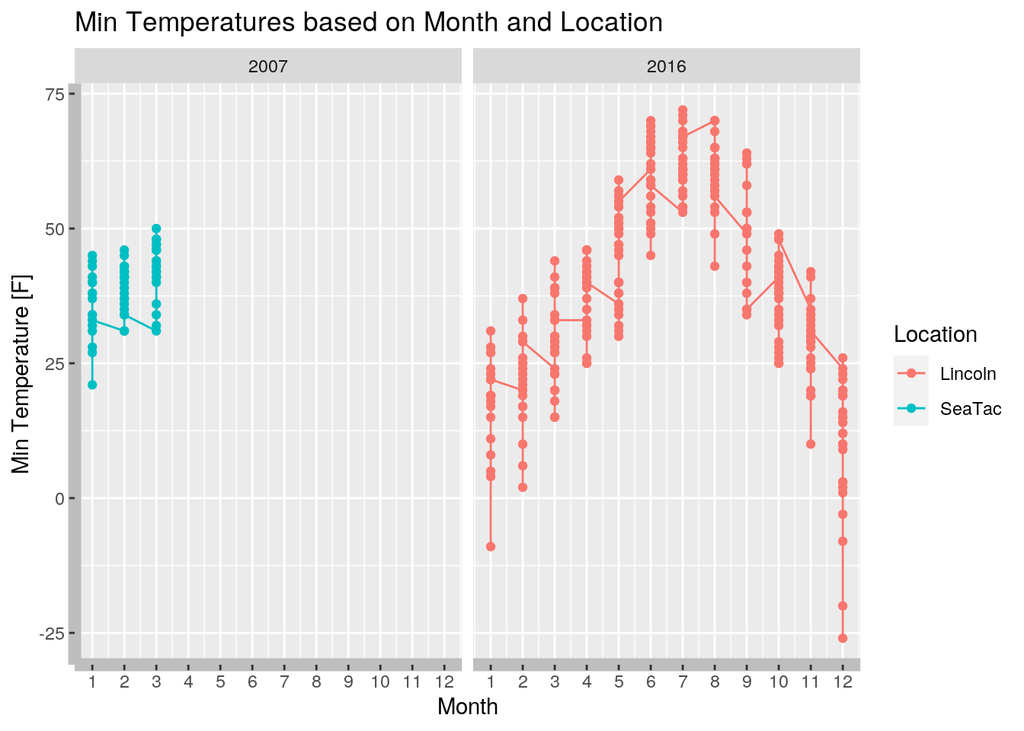

```r
Weather %>% ggplot(mapping = aes(x = Month, y = MinTemp, color = Location)) +
    geom_point() + geom_line() + facet_wrap(~Year) + ylab("Min Temperature [F]") +
    scale_x_continuous(breaks = seq(0, 12, 1)) + ggtitle("Min Temperatures based on Month and Location") +
    theme(axis.line = element_line(size = 3, color = "grey"))
```

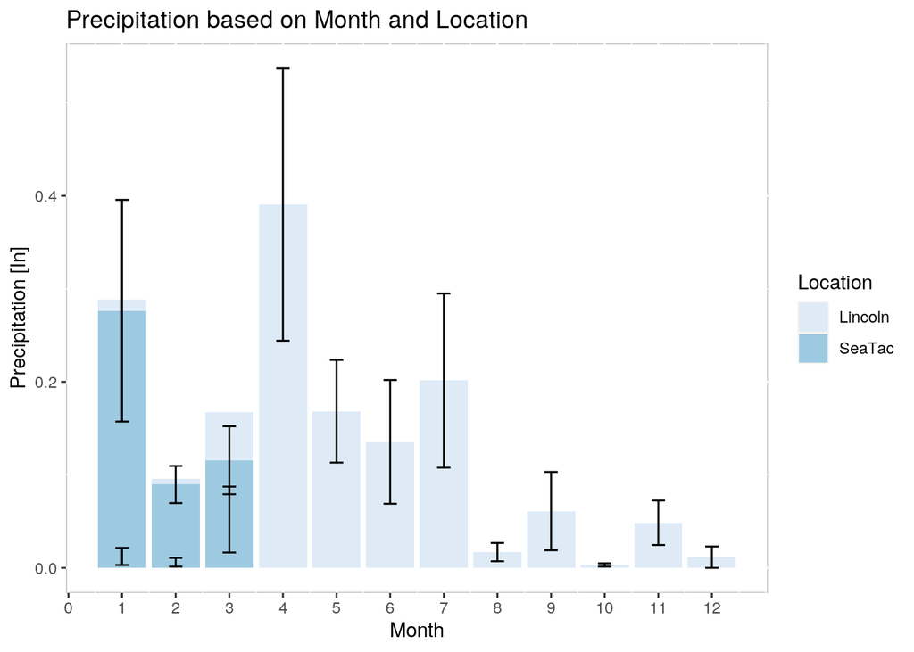

```r
Weather %>% ggplot(mapping = aes(x = Month, y = Precipitation,
    fill = Location)) + geom_bar(stat = "summary", fun = mean) +
    ylab("Precipitation [In]") + scale_x_continuous(breaks = seq(0,
    12, 1)) + ggtitle("Precipitation based on Month and Location") +
    geom_errorbar(stat = "summary", fun.data = mean_se, width = 0.25) +
    scale_fill_brewer() + theme(panel.background = element_rect(fill = "white",
    color = "grey"))
```